# MicroArray Analysis with Limma

Marta del Olmo

1/21/2021

**1. Reading and processing microarray files -> normalization, background correction, duplicate-averaging**

**2. Analysis at the level of tissues: design matrix, fits**

**3. Plotting results of (2) in either-or: number of rhythmic genes, amplitudes, phases, GO, KEGG**

**4. Differential rhythmicity analysis: expressed + rhythmic genes in both**

### **Choosing cutoffs**

```r
fdr_cutoff <- 0.05
amp_cutoff <- log2(1 + 0.2)
```

## **1. Reading and processing microarray files**

Read the file `raw_MA_files.RDS` inside `data/` if it already exists. If not, create this file from the raw data (`extra/Skin Data/raw data/`) and annotate the probes.

```r
if (!file.exists("data/raw_MA_files.RDS")){
  ##--------------Read in image files-------------------------------------------------------##
  files <- list.files("/extra/Skin Data/raw data/", full.names = TRUE)
  m <- regexpr("(D|E)\\d+_P\\d+", files, perl = TRUE)
  names <- regmatches(files, m)
  images <- read.maimages(files = files, source = "agilent", green.only = TRUE, names = names,
                          other.columns = "gIsWellAboveBG")

  ##--------annotation of probes------------------------------------------------------------##
  images$genes$Symbol <- mapIds(hgug4112a.db, images$genes$ProbeName, keytype = "PROBEID", column = "SYMBOL")
  images$genes$ENSEMBL <- mapIds(hgug4112a.db, images$genes$ProbeName, keytype = "PROBEID", column = "ENSEMBL")
  images$genes$EntrezID <- mapIds(hgug4112a.db, images$genes$ProbeName, keytype = "PROBEID", column = "ENTREZID")

  saveRDS(images, file = "data/raw_MA_files.RDS",compress = "gzip")
} else {
  images <- readRDS("data/raw_MA_files.RDS")
}
```

Microarray data has to be **background-corrected** and then **normalized**. We use the `normexp` method for background correction (preferred when background intensities are not known) and `quantile` for normalization between the different arrays.

```r
if (!file.exists("visualize/data/rawdata.rds")){
  y <- limma::backgroundCorrect(images, method = "normexp")
  y <- normalizeBetweenArrays(y, method = "quantile")
}
```

Now we can filter out:

1. Controls (needed for background correction)
2. Probes that are not annotated
3. Those lowly-expressed samples -> *Typically half of the total number of samples, but we could take half of the samples from each patient.* *This can be revisited later on.* (Tradeoff strictness-results)

And average probes that map to the same gene. Typically microarray experiments include the so called **probesets**, which are oligos that target the same transcripts and that are located at different places of the chip or even in different chips. Thus, we have to correct for this redundancy. We do this in `yave`.

```r
if (!file.exists("visualize/data/rawdata.rds")){
  Control <- y$genes$ControlType==1L #Control <- y$genes$ControlType==1 would also work
  NoID    <- is.na(y$genes$ENSEMBL)
  IsExpr  <- rowSums(y$other$gIsWellAboveBG>0) >= 77

  y0 <- y[!Control & !NoID & IsExpr, ]  # Data (expressed, identified, not controls) with gene annotation
  y0$genes <- y0$genes[, c("ProbeName", "Symbol", "ENSEMBL", "EntrezID")]

  yave <- avereps(y0, y0$genes[, "ENSEMBL"])  # Averaging probes mapping to the same gene
  rownames(yave$E) <- yave$genes$ProbeName
}
```

We can now save this processed file.

```r
if (!file.exists("visualize/data/rawdata.rds")){
  saveRDS(yave, file = "visualize/data/rawdata.rds")
} else {
  yave <- readRDS("visualize/data/rawdata.rds")
}
```

## **2. Analysis at the level of tissues**

The objective of this section is **to look for average population rhythms in a tissue.**

We first extract the sample details from the column names, i.e., we build a dataframe with the tissue, time and subject # of the sample.

Note for me: `y0` is only defined when we are processing the data (so when the rawdata.rds file does NOT exist). That’s why the next chunk appears inside an if(!file.exists()) statement. If the file already exists, I just load it and extract sample details.

```r
if (!file.exists("visualize/data/rawdata.rds")){
  ##----------------------extracting sample details from column names ----------------------##
  experiment <- data.frame(tissue = character(), time = integer(), subject = character()) %>%
                {strcapture("(\\w)(\\d+)_(\\w+)", colnames(y0$E), ., perl = TRUE)}

  tissue  <- factor(experiment$tissue)
  time    <- experiment$time
  subject <- factor(experiment$subject)

  saveRDS(experiment, "visualize/data/experiment.rds")
} else{
  experiment <- readRDS("visualize/data/experiment.rds")

  tissue  <- factor(experiment$tissue)
  time    <- experiment$time
  subject <- factor(experiment$subject)
}
```

Now the key part comes: to **construct the multi-level design matrix** and **fit the data**.

### **2.1. Multi-level design matrix**

1. We first have to define the two frequency components, `inphase` and `outphase` of the times at which samples were taken (i.e. 8, 12, 16, 20, 24, 28, 32). *Note that we need the two $sin()$ and $cos()$ components because what we do is similar to a Fourier transform, to extract frequency info we need both.* -> READ

```r
inphase  <- cos(2*pi*time/24)
outphase <- sin(2*pi*time/24) #~ to fourier, to extract freq. info
```

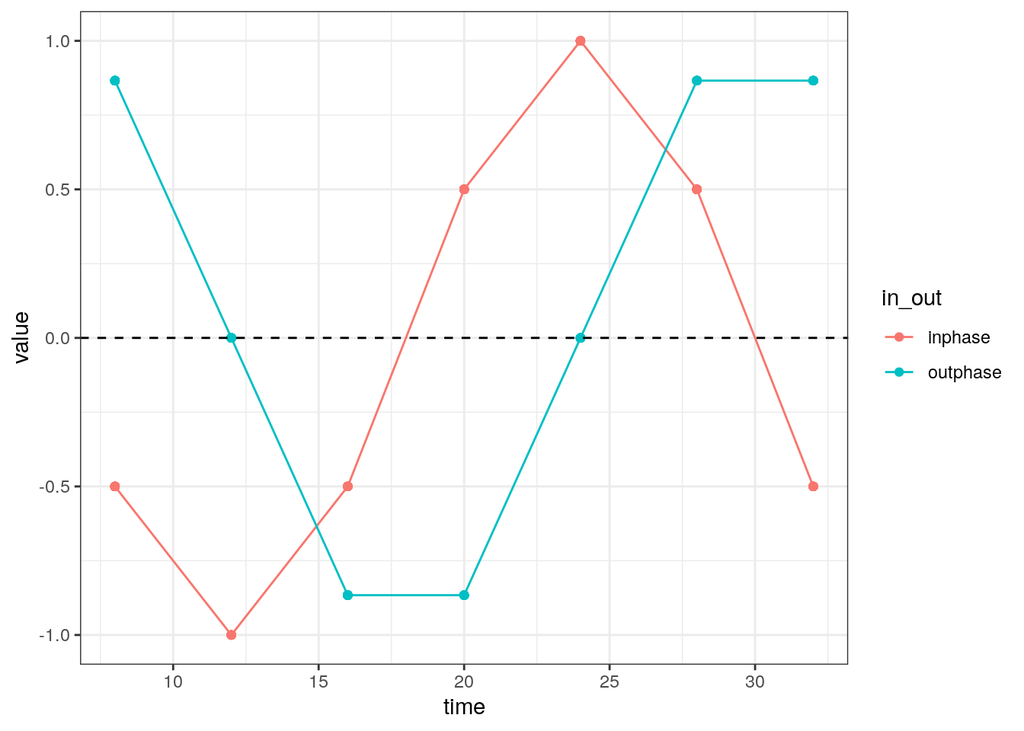

2. Now we define how we will perform the hypothesis testing. We follow an ANOVA approach (good for balanced designs). Note that the results will depend on our hypothesis testing. For example:
- `model.matrix(~ subject + tissue) %>% head()` -> I am saying that my $H_0$ is that there is no difference between subjects and p100_Dermis. My reference in this case is p100Dermis. Subject and tissue are independent *categorical variables* because htey are separated by $+$ and there are no $:$ signs that denote interaction of such variables
- `model.matrix(~ 0 + subject + tissue + inphase + outphase)` -> subject, tissue and time are independent categorical variables. In this case, the 0 indicates that p100Dermis is not the reference. Thus, all samples are compared among themselves (we will see that I don’t have anymore an `Intercept` column, but a `p100` column instead)
- `model.matrix(~ 0 + subject + tissue + tissue:inphase + tissue:outphase)` -> here, we have subject and tissue as independent variables, but the colon `:` means interaction between the variables. Thus, we are saying that the coefficients that we obtain for inphase/outphase should be different for each tissue.
- A number of variables could be added here, for example sex. But keep in mind that the more terms we have in the `model.matrix`, the worse the $p$ values will be

```r
design <- model.matrix(~ 0 + subject + tissue + tissue:inphase + tissue:outphase)
```

### **2.2. Fitting the data**

To fit the data:

```r
wts <- limma::arrayWeights(yave, model.matrix(~tissue + subject))
    # model.matrix: simpler model used as suggested in userguide. (avoid?)
fit <- limma::lmFit(yave, design)#, weights = wts)
fit2 <- limma::eBayes(fit, trend = TRUE, robust = TRUE)
```

4. We organize the tissue:inphase and tissue:outphase results from `fit2` (i.e., the coefficients) together with gene annotations and statistics results, not caring about subject or tissue differences at this point. $p$ values are adjusted for multiple testing by Benjamini Hochberg. -> Where does it get the $F, p$ and adjusted $p$ values from?

```r
rhy_indices <- which(grepl("phase",colnames(design)))
if (!file.exists("visualize/data/results.rds")){
  results <- limma::topTable(fit2, coef = rhy_indices, number = Inf, sort.by = "none") %>%
    set_colnames(gsub("\\.","_", colnames(.)))
  saveRDS(results, file = "visualize/data/results.rds")
}
```

## **3. Plotting analysis at tissue level**

From the `inphase/outphase` fitting coefficients, we can determine amplitude and phase of the oscillation of the gene that annotates to that probe.

```r
results <- readRDS("visualize/data/results.rds")
results %<>% #results %<>% == results <- results %>%
  dplyr::mutate(A_D = sqrt(tissueD_inphase^2 + tissueD_outphase^2), #Amp = cos**2 + sin**2 (note the log2 values)
  A_E = sqrt(tissueE_inphase^2 + tissueE_outphase^2),
  phaseD = atan2(tissueD_outphase, tissueD_inphase)*12/pi,
           #atan2 takes two arguments, y and x, atan just takes the angle
  phaseE = atan2(tissueE_outphase, tissueE_inphase)*12/pi)
```

### 3.1. Number of rhythmic genes somewhere (in **either or** tissue) depending on the adjusted $p$ value

Let’s plot how many rhythmic genes we end up with (with the `amp_cutoff` that we chose), depending on the `adj_P_Val`. Note that we filter our `results` data frame by saying that we get that probe whose dermis_Amp (`A_D`) **or** epidermis_Amp (`A_E`)i s above the threshold. Our condition is **OR**, and not **BOTH**.

[figure not shown]

```r
plot_Noofgenes <- ggplot(data = dplyr::filter(results, pmax(A_D, A_E) > amp_cutoff) %>%
                           dplyr::mutate(len = length(adj_P_Val))) +
        #pmax gives the maximum of each zipped pair of values A_D[i], A_E[i]
    stat_ecdf(aes(x = adj_P_Val, len=len, y = ..y..*len), geom = "step") +
        #we don't want fraction of genes (default of ecdf) but number, that's why we *len
    coord_cartesian(xlim = c(0.001, 0.05), ylim = c(0,2000)) + theme_bw() +
    xlab("False discovery rate") + ylab("number of rhythmic genes")

if (!file.exists("figures/Noofgenes.pdf")){
  plot_Noofgenes %T>% ggsave("figures/Noofgenes.pdf", .)
  # T pipe works like %>% but it returns  the left-hand side instead of the right-hand
}

plot_Noofgenes
```

### **3.2. Comparison of amplitudes and phases in dermis vs. epidermis**

Let’s now plot how the amplitudes in dermis correlate with amplitudes in epidermis, and same with phases.

Again, we filter our data to end up with those genes whose amplitude is $>$ than the `amp_cutoff` and now also we are interested in those genes whose adjusted $p$ value is $<$ `fdr_cutoff`. Note that we are filtering again in an **either-or** way (either `A_D` or `A_E` $>$ cutoff). But, if I end up with scenarios in which the amplitude in one tissue is $<$ than the cutoff (see `dplyr::filter(results, ProbeName %in% some_rhythm) %>% head`, row4), how come I don’t see this point in the plot?

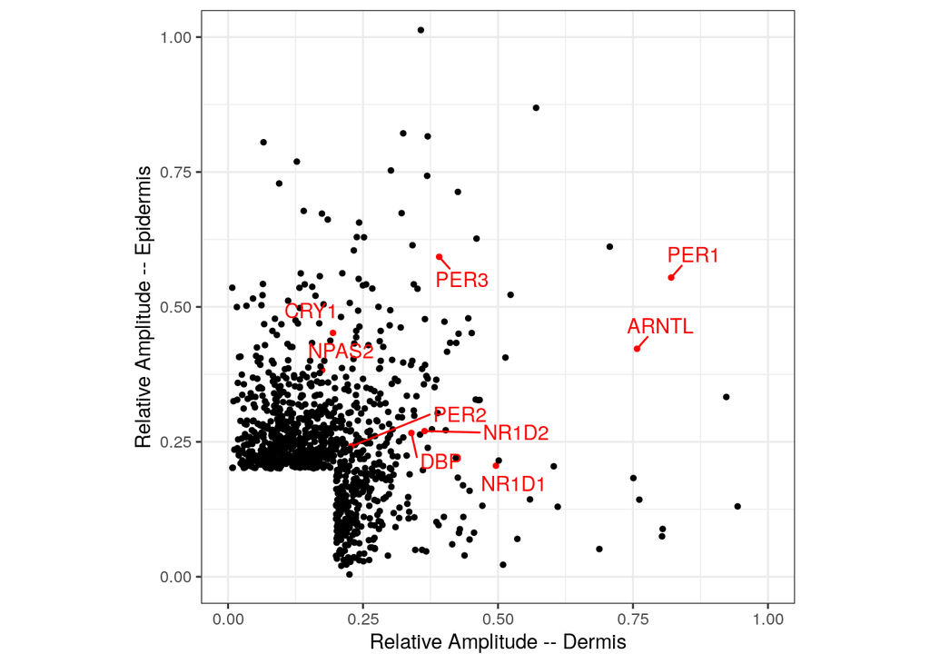

```r
some_rhythm <- dplyr::filter(results, pmax(A_D, A_E) > amp_cutoff & adj_P_Val < fdr_cutoff) %$% ProbeName

clock_genes <- c("PER1","PER2","PER3", "CRY1", "CRY2", "NR1D1", "NR1D2", "ARNTL", "ARNTL2", "CLOCK",
                 "NPAS2","RORA","RORB","RORC", "CSNK1D", "CSNK1E", "DBP")

plot_Amplitude_compare <- ggplot(data = dplyr::filter(results, ProbeName %in% some_rhythm),
                                 aes(x=2^A_D-1, y=2^A_E-1)) + #amps are in log2
  geom_point(aes(color=Symbol %in% clock_genes), size=1) +
  geom_text_repel(aes(label=ifelse(Symbol %in% clock_genes, as.character(Symbol), "")), color="red",
                  max.overlaps=Inf, box.padding = 0.5) +
  scale_color_manual(values=c("black","red")) +
  theme_bw() + theme(aspect.ratio = 1, legend.position = "none") + coord_cartesian(xlim=c(0,1), ylim = c(0,1)) +
  xlab("Relative Amplitude -- Dermis") + ylab("Relative Amplitude -- Epidermis")

if (!file.exists("figures/Amplitude_compare.pdf")){
  plot_Amplitude_compare %>% ggsave("figures/Amplitude_compare.pdf", .)
}

plot_Amplitude_compare
```

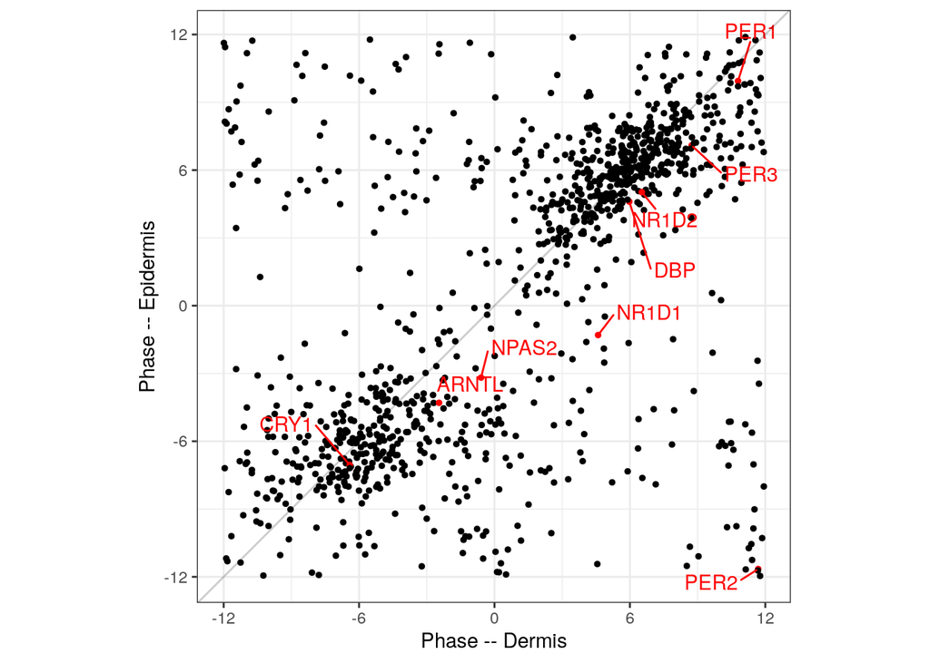

```r
plot_Phase_compare <- ggplot(data = dplyr::filter(results, ProbeName %in% some_rhythm),
                             aes(x=phaseD, y=phaseE)) +
  geom_point(aes(color=Symbol %in% clock_genes), size=1) +
  geom_text_repel(aes(label=ifelse(Symbol %in% clock_genes, as.character(Symbol), "")), color="red",
                  max.overlaps=Inf, box.padding = 0.5) +
  scale_color_manual(values=c("black","red")) +
  theme_bw() + theme(aspect.ratio = 1, legend.position = "none") + geom_abline(slope = 1, alpha=0.2) +
  scale_x_continuous(breaks = seq(-12,12,by = 6)) +
  scale_y_continuous(breaks = seq(-12,12,by = 6)) +
  xlab("Phase -- Dermis") + ylab("Phase -- Epidermis")

if (!file.exists("figures/Phase_compare.pdf")){
  plot_Phase_compare %>% ggsave("figures/Phase_compare.pdf", .)
}

plot_Phase_compare
```